# Final Project

Alex Coleman

2022-11-30

```r
library(fpp3)
```

```r
library(fable)
library(ggplot2)
library(dplyr)
```

```r
url2 <- "https://fred.stlouisfed.org/graph/fredgraph.csv?bgcolor=%23e1e9f0&chart_type=line&drp=0&fo=open%20sans&graph_bgcolor=%23ffffff&height=450&mode=fred&recession_bars=on&txtcolor=%23444444&ts=12&tts=12&width=1168&nt=0&thu=0&trc=0&show_legend=yes&show_axis_titles=yes&show_tooltip=yes&id=CPALTT01USM659N&scale=left&cosd=1960-01-01&coed=2022-09-01&line_color=%234572a7&link_values=false&line_style=solid&mark_type=none&mw=3&lw=2&ost=-99999&oet=99999&mma=0&fml=a&fq=Monthly&fam=avg&fgst=lin&fgsnd=2020-02-01&line_index=1&transformation=lin&vintage_date=2022-11-29&revision_date=2022-11-29&nd=1960-01-01"

CPI <- read.csv(url2, header = TRUE)

head(CPI)
```

```
##         DATE CPALTT01USM659N
## 1 1960-01-01        1.034483
## 2 1960-02-01        1.730104
## 3 1960-03-01        1.730104
## 4 1960-04-01        1.724138
## 5 1960-05-01        1.724138
## 6 1960-06-01        1.718213
```

```r
url3 <- "https://fred.stlouisfed.org/graph/fredgraph.csv?bgcolor=%23e1e9f0&chart_type=line&drp=0&fo=open%20sans&graph_bgcolor=%23ffffff&height=450&mode=fred&recession_bars=on&txtcolor=%23444444&ts=12&tts=12&width=1168&nt=0&thu=0&trc=0&show_legend=yes&show_axis_titles=yes&show_tooltip=yes&id=MORTGAGE30US&scale=left&cosd=1971-04-02&coed=2022-11-23&line_color=%234572a7&link_values=false&line_style=solid&mark_type=none&mw=3&lw=2&ost=-99999&oet=99999&mma=0&fml=a&fq=Weekly%2C%20Ending%20Thursday&fam=avg&fgst=lin&fgsnd=2020-02-01&line_index=1&transformation=lin&vintage_date=2022-11-29&revision_date=2022-11-29&nd=1971-04-02"

fixed_mortgage_rate <- read.csv(url3, header = TRUE)
head(fixed_mortgage_rate)
```

```
##         DATE MORTGAGE30US
## 1 1971-04-02         7.33
## 2 1971-04-09         7.31
## 3 1971-04-16         7.31
## 4 1971-04-23         7.31
## 5 1971-04-30         7.29
## 6 1971-05-07         7.38
```

I chose this dataset because I am interested in forecasting this as it seems to be increasing and would like to see if I can make a solid forecast model that will accurately forecast the future and I have interest in the real estate market as well. One of my roommates is making an algorithm that looks at Zillow and is focused in and around our hometown of Loveland Ohio and I figured this would be a good project to go with it.

This can hopefully help potential homebuyers decide if it is the right time for them to purchase a house. For some of my roommates we are interested in investing in real estate (once we aren’t poor) and enjoy learning about the market as well. I predict mortgage rates will raise in the future and hopefully this will predict the same. Assuming there is a recession now and potentially a depression in the future, that would be the best time start buying property and capitalize off it. Being able to predict Interest rates would help us make better decisions when it comes to buying real estate especially since the real estate industry is so diluted with so many people wanting to be real estate agents, flip homes, rent out homes, etc, having key data to help make better decisions could be factor in being successful.

```r
fixed_mortgage_rate_Month <- fixed_mortgage_rate %>%
  mutate(Date = ymd(DATE),
  Month = yearmonth(Date)) %>%
select(-DATE, -Date)



head(fixed_mortgage_rate_Month)
```

```
##   MORTGAGE30US    Month
## 1         7.33 1971 Apr
## 2         7.31 1971 Apr
## 3         7.31 1971 Apr
## 4         7.31 1971 Apr
## 5         7.29 1971 Apr
## 6         7.38 1971 May
```

```r
CPI_Month <- CPI %>%
  mutate(Date = ymd(DATE),
  Month = yearmonth(Date)) %>%
  filter(Date >= "1971-04-01" ) %>%
select(-DATE, -Date)


head(CPI_Month)
```

```
##   CPALTT01USM659N    Month
## 1        4.155844 1971 Apr
## 2        4.404145 1971 May
## 3        4.639175 1971 Jun
## 4        4.358974 1971 Jul
## 5        4.615385 1971 Aug
## 6        4.081633 1971 Sep
```

```r
Dataset <- full_join(fixed_mortgage_rate_Month, CPI_Month, by = "Month")


  head(Dataset)
```

```
##   MORTGAGE30US    Month CPALTT01USM659N
## 1         7.33 1971 Apr        4.155844
## 2         7.31 1971 Apr        4.155844
## 3         7.31 1971 Apr        4.155844
## 4         7.31 1971 Apr        4.155844
## 5         7.29 1971 Apr        4.155844
## 6         7.38 1971 May        4.404145
```

```r
Dataset_tsb <- Dataset %>%
  mutate(Week_number = row_number(),
          fixed_rate =MORTGAGE30US,
         CPI = CPALTT01USM659N,
         Three_month_lag_CPI = lag(CPI, n = 12L),
         Two_month_lag_CPI = lag(CPI, n = 8L),
        one_year_lag_fixed_rate = lag(fixed_rate, n=52L)) %>%
  as_tsibble(index = Week_number, regular = TRUE) %>%
  filter(!is.na(Three_month_lag_CPI), !is.na(one_year_lag_fixed_rate), !is.na(Two_month_lag_CPI)) %>%
  select(-MORTGAGE30US,
         -CPALTT01USM659N)


Dataset_tsb
```

```
## # A tsibble: 2,644 x 7 [1]
##       Month Week_number fixed_rate   CPI Three_month_lag_CPI Two_month…¹ one_y…²
##       <mth>       <int>      <dbl> <dbl>               <dbl>       <dbl>   <dbl>
##  1 1972 Mar          53       7.23  3.50                3.27        3.51    7.33
##  2 1972 Apr          54       7.25  3.49                3.27        3.51    7.31
##  3 1972 Apr          55       7.29  3.49                3.27        3.51    7.31
##  4 1972 Apr          56       7.29  3.49                3.27        3.51    7.31
##  5 1972 Apr          57       7.33  3.49                3.51        3.50    7.29
##  6 1972 May          58       7.33  3.23                3.51        3.50    7.38
##  7 1972 May          59       7.38  3.23                3.51        3.50    7.42
##  8 1972 May          60       7.38  3.23                3.51        3.50    7.44
##  9 1972 May          61       7.4   3.23                3.50        3.50    7.46
## 10 1972 Jun          62       7.36  2.71                3.50        3.49    7.52
## # … with 2,634 more rows, and abbreviated variable names ¹Two_month_lag_CPI,
## #   ²one_year_lag_fixed_rate
```

I added Month columns to both he CPI dataset and fixed mortgage dataset so i could merge them without having to separate date tables as fixed mortgage was weekly statistics and CPI was monthly.

I made the row_number of the data into the week_number and used it as the index as I struggled to find an alternate way to be able to covert the data to a tsibble.

I changed the names to make the CPI and fixed rate columns on the dataset more identifiable by mutating them and giving them a new name and deleting the old names.

I added Two_month_lag_CPI, Three_month_lag_CPI, and one_year_fixed_rate_lag to use as predictor variables and see fi there was any correlation or trend between them and fixed rate.

I used !is.na to take out any missing data.

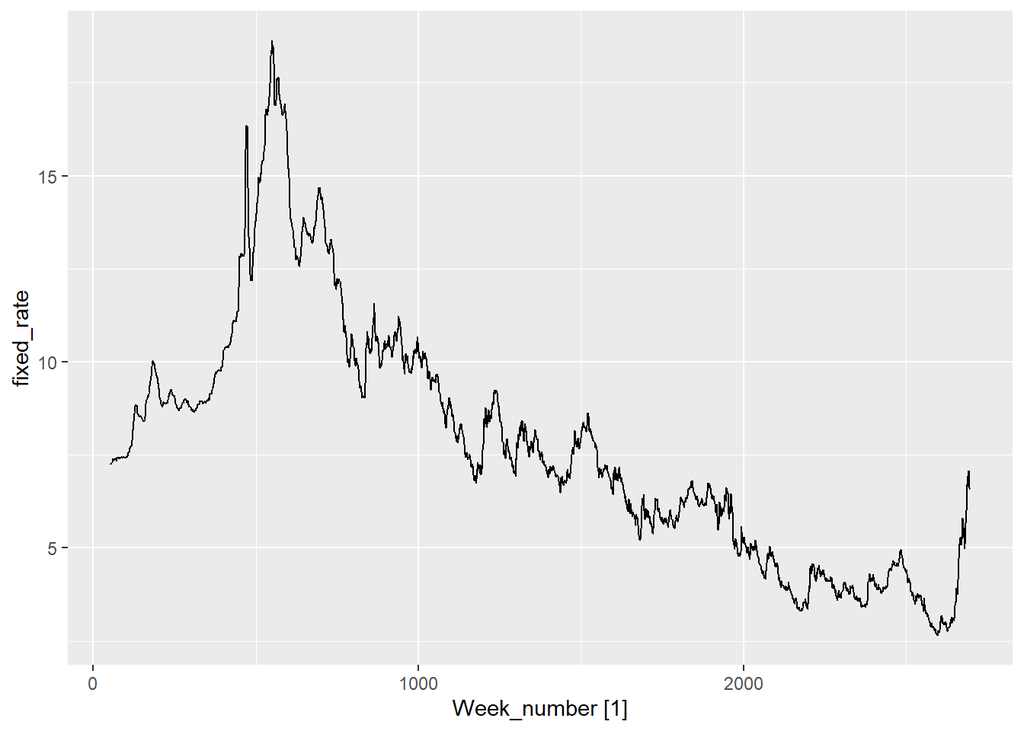

```r
Dataset_tsb %>% autoplot(fixed_rate)
```

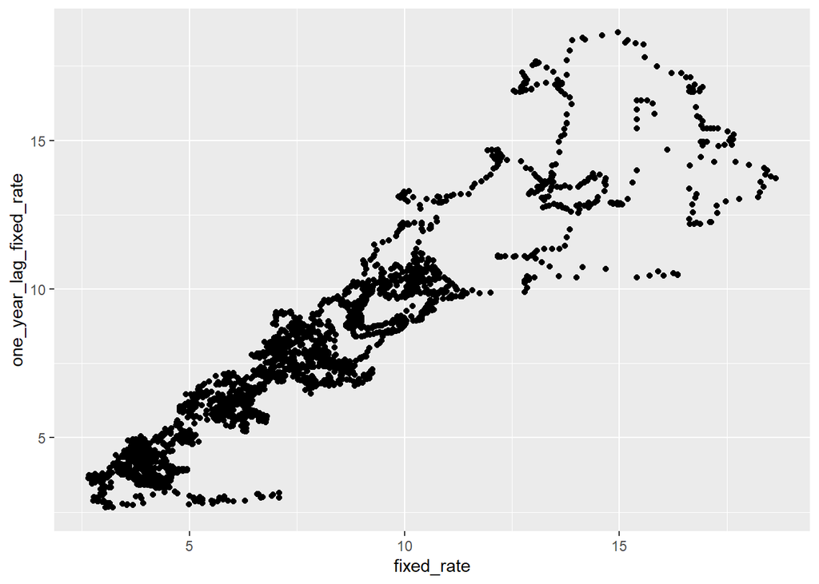

```r
Dataset_tsb %>% ggplot(aes(x = fixed_rate, y = one_year_lag_fixed_rate)) +
geom_point()
```

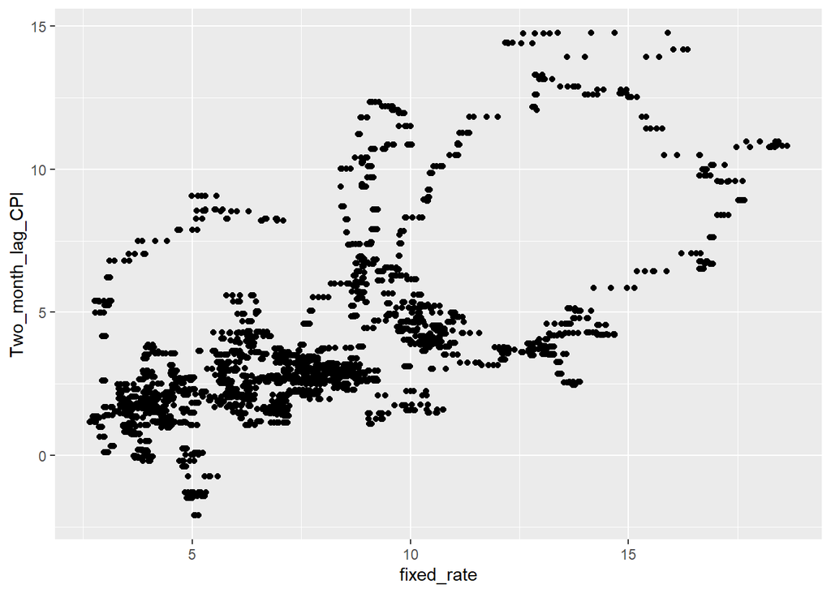

```r
Dataset_tsb %>% ggplot(aes(x = fixed_rate, y = Two_month_lag_CPI)) +
geom_point()
```

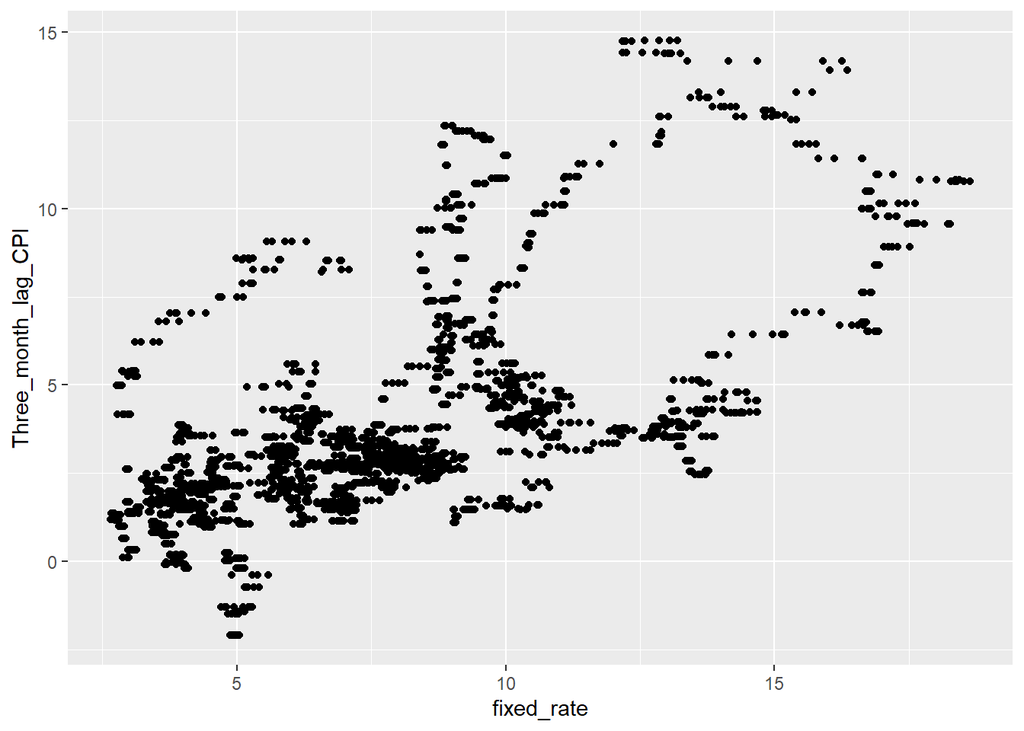

```r
Dataset_tsb %>% ggplot(aes(x = fixed_rate, y = Three_month_lag_CPI )) +
geom_point()
```

It looks like it has cycle pattern of going up and down over the years but seems relatively random with when and how long the cycles last.

From 1971 to the early 80’s the fixed mortgage rate is increasing rapidly.

From mid 1980’s it is on a relative downward trend until around mid to late 2020.

The anomaly of the fixed mortgage rate increasing rapidly from 1971 to the early 80s is most likely do to the instability in the economy at the time as there was a recession in the US from November 1973-March of 1975 as well as January 1980-July 1980 and July 1981-November 1982.

From 1971 to early 1980’s there is a upward trend in fixed mortgage rate, from early to mid 1980’s to 2020 there is a gradual trend downward.

There does seem to cycles of the rate moving up or down over periods of time which is to be expected.

It seems after the pandemic started in 2020 the downward trend switched to an upward trend.

We will use the two month , three month lag of CPI, and one year lag of the fixed rate as predictors since there is levels of correlation in all.

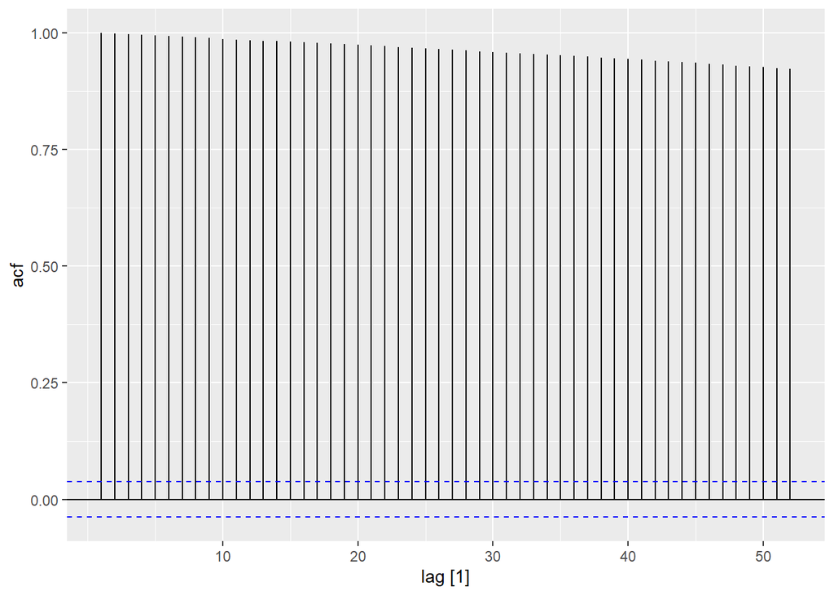

```r
Dataset_tsb %>% ACF(fixed_rate, lag_max = 52) %>% autoplot
```

```r
Dataset_tsb %>% features(fixed_rate, unitroot_kpss)
```

```
## # A tibble: 1 × 2
##   kpss_stat kpss_pvalue
##       <dbl>       <dbl>
## 1      19.2        0.01
```

```r
Dataset_tsb %>% features(fixed_rate, unitroot_nsdiffs)
```

```
## # A tibble: 1 × 1
##   nsdiffs
##     <int>
## 1       0
```

```r
Dataset_tsb %>% features(fixed_rate, unitroot_ndiffs)
```

```
## # A tibble: 1 × 1
##   ndiffs
##    <int>
## 1      1
```

```r
Dataset_tsb %>% features(difference(fixed_rate), unitroot_kpss)
```

```
## # A tibble: 1 × 2
##   kpss_stat kpss_pvalue
##       <dbl>       <dbl>
## 1     0.144         0.1
```

The data looks autocorrelated from a ACF test

From Kpss test it shows the dataset is not stationary.

The dataset does not need not need a seasonal difference.

The dataset does need a difference.

The dataset is stationary after taking a difference of fixed rate.

```r
Dataset_tsb_updated <- Dataset_tsb %>%
  mutate(diff_fixed_rate = difference(fixed_rate), lag_diff_fixed_rate = lag(diff_fixed_rate)) %>%
           filter(!is.na(diff_fixed_rate), !is.na(lag_diff_fixed_rate))

Dataset_tsb_updated
```

```
## # A tsibble: 2,642 x 9 [1]
##       Month Week_number fixed_rate   CPI Three…¹ Two_m…² one_y…³ diff_…⁴ lag_d…⁵
##       <mth>       <int>      <dbl> <dbl>   <dbl>   <dbl>   <dbl>   <dbl>   <dbl>
##  1 1972 Apr          55       7.29  3.49    3.27    3.51    7.31  0.0400  0.0200
##  2 1972 Apr          56       7.29  3.49    3.27    3.51    7.31  0       0.0400
##  3 1972 Apr          57       7.33  3.49    3.51    3.50    7.29  0.0400  0
##  4 1972 May          58       7.33  3.23    3.51    3.50    7.38  0       0.0400
##  5 1972 May          59       7.38  3.23    3.51    3.50    7.42  0.0500  0
##  6 1972 May          60       7.38  3.23    3.51    3.50    7.44  0       0.0500
##  7 1972 May          61       7.4   3.23    3.50    3.50    7.46  0.0200  0
##  8 1972 Jun          62       7.36  2.71    3.50    3.49    7.52 -0.0400  0.0200
##  9 1972 Jun          63       7.38  2.71    3.50    3.49    7.52  0.0200 -0.0400
## 10 1972 Jun          64       7.38  2.71    3.50    3.49    7.54  0       0.0200
## # … with 2,632 more rows, and abbreviated variable names ¹Three_month_lag_CPI,
## #   ²Two_month_lag_CPI, ³one_year_lag_fixed_rate, ⁴diff_fixed_rate,
## #   ⁵lag_diff_fixed_rate
```

```r
train <- Dataset_tsb_updated %>% filter(year(Month) < 2018)
test <- Dataset_tsb_updated %>% filter(year(Month) >= 2018)
```

I chose to split at 2018 because I believe it gives the training set a lot of previous data to use and still offers sufficient data from 2018 onwards to test against.

```r
FitTSLModels <- train %>% model( lm1 = TSLM(diff_fixed_rate ~ Two_month_lag_CPI),
                           lm2 = TSLM(diff_fixed_rate ~ Three_month_lag_CPI),
                           lm3 = TSLM(diff_fixed_rate ~ Two_month_lag_CPI + Three_month_lag_CPI),
                           lm4 = TSLM(diff_fixed_rate ~ Two_month_lag_CPI +Three_month_lag_CPI + one_year_lag_fixed_rate))




FitTSLModels %>% glance
```

```
## # A tibble: 4 × 15
##   .model r_squared adj_r_…¹ sigma2 stati…² p_value    df log_lik     AIC    AICc
##   <chr>      <dbl>    <dbl>  <dbl>   <dbl>   <dbl> <int>   <dbl>   <dbl>   <dbl>
## 1 lm1      0.00365  0.00324 0.0123    8.74 3.14e-3     2   1862. -10490. -10490.
## 2 lm2      0.00290  0.00248 0.0123    6.94 8.49e-3     2   1861. -10488. -10488.
## 3 lm3      0.00590  0.00506 0.0123    7.07 8.68e-4     3   1865. -10493. -10493.
## 4 lm4      0.0109   0.00966 0.0122    8.75 9.01e-6     4   1871. -10503. -10503.
## # … with 5 more variables: BIC <dbl>, CV <dbl>, deviance <dbl>,
## #   df.residual <int>, rank <int>, and abbreviated variable names
## #   ¹adj_r_squared, ²statistic
```

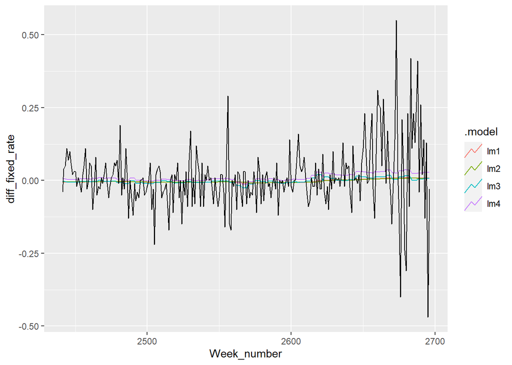

```r
fc <- FitTSLModels %>%
  forecast(new_data = test)
fc %>% autoplot(test, level =NULL)
```

```r
FitTSLModels %>% glance
```

```
## # A tibble: 4 × 15
##   .model r_squared adj_r_…¹ sigma2 stati…² p_value    df log_lik     AIC    AICc
##   <chr>      <dbl>    <dbl>  <dbl>   <dbl>   <dbl> <int>   <dbl>   <dbl>   <dbl>
## 1 lm1      0.00365  0.00324 0.0123    8.74 3.14e-3     2   1862. -10490. -10490.
## 2 lm2      0.00290  0.00248 0.0123    6.94 8.49e-3     2   1861. -10488. -10488.
## 3 lm3      0.00590  0.00506 0.0123    7.07 8.68e-4     3   1865. -10493. -10493.
## 4 lm4      0.0109   0.00966 0.0122    8.75 9.01e-6     4   1871. -10503. -10503.
## # … with 5 more variables: BIC <dbl>, CV <dbl>, deviance <dbl>,
## #   df.residual <int>, rank <int>, and abbreviated variable names
## #   ¹adj_r_squared, ²statistic
```

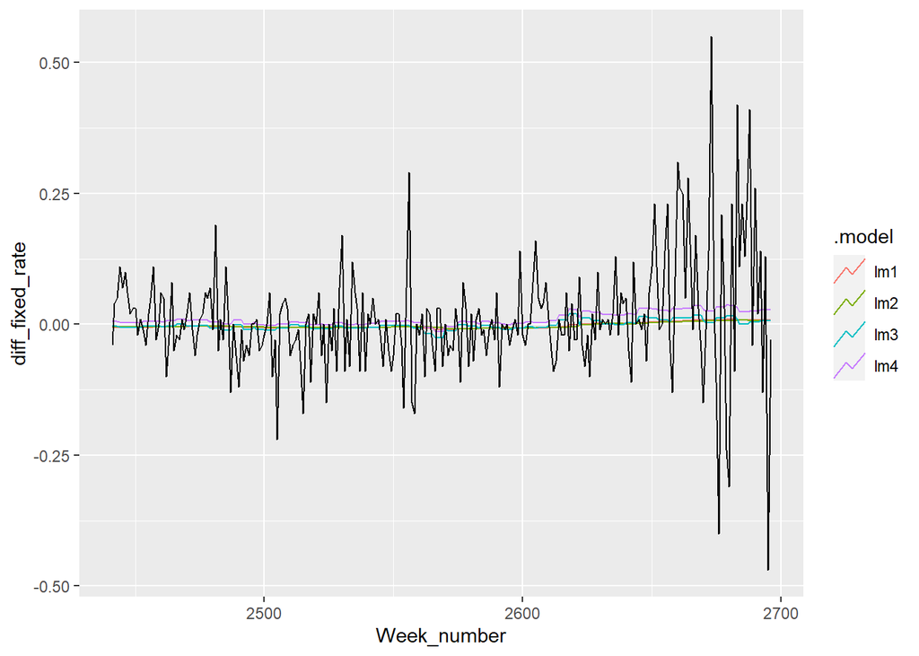

```r
fc <- FitTSLModels %>%
  forecast(new_data = test)
fc %>% autoplot(test, level =NULL)
```

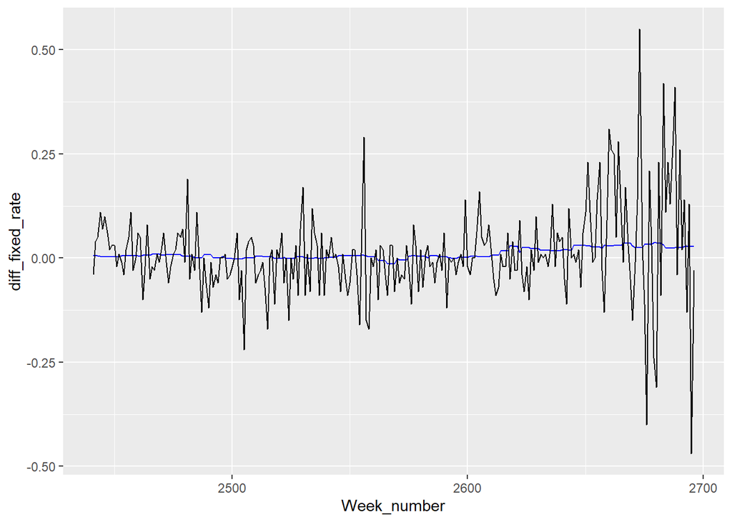

```r
TSLMBESTMODEL <- train %>% model(TSLMBEST = TSLM(diff_fixed_rate ~ Two_month_lag_CPI +Three_month_lag_CPI + one_year_lag_fixed_rate))

fctslm <- TSLMBESTMODEL %>%
  forecast(new_data = test)
fctslm %>% autoplot(test, level =NULL)
```

This model I chose is due to it having the lowest AICc at first I added many more predictor variables but deleted them as I felt I had over fitted the model.

```r
glance(TSLMBESTMODEL)
```

```
## # A tibble: 1 × 15
##   .model   r_squa…¹ adj_r…² sigma2 stati…³ p_value    df log_lik     AIC    AICc
##   <chr>       <dbl>   <dbl>  <dbl>   <dbl>   <dbl> <int>   <dbl>   <dbl>   <dbl>
## 1 TSLMBEST   0.0109 0.00966 0.0122    8.75 9.01e-6     4   1871. -10503. -10503.
## # … with 5 more variables: BIC <dbl>, CV <dbl>, deviance <dbl>,
## #   df.residual <int>, rank <int>, and abbreviated variable names ¹r_squared,
## #   ²adj_r_squared, ³statistic
```

```r
AUG <- augment(TSLMBESTMODEL)
AUG %>% features(.innov, ljung_box, lag = 12, dof = 7 )
```

```
## # A tibble: 1 × 3
##   .model   lb_stat lb_pvalue
##   <chr>      <dbl>     <dbl>
## 1 TSLMBEST    512.         0
```

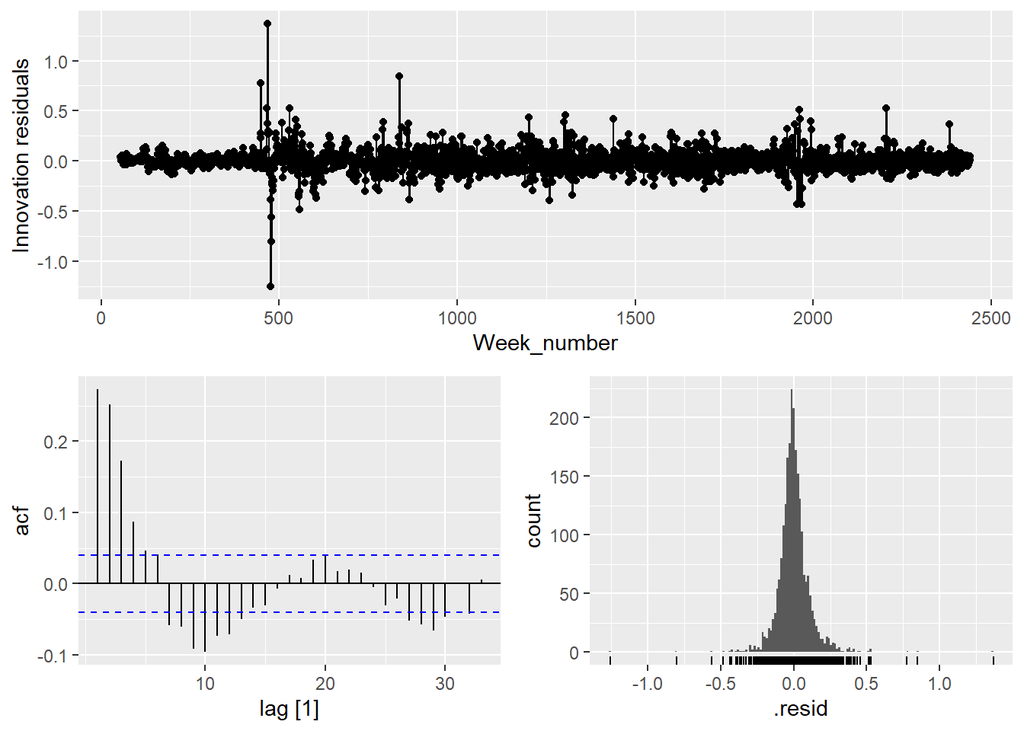

```r
TSLMBESTMODEL %>% gg_tsresiduals()
```

```r
AUG %>% features(.innov, unitroot_kpss)
```

```
## # A tibble: 1 × 3
##   .model   kpss_stat kpss_pvalue
##   <chr>        <dbl>       <dbl>
## 1 TSLMBEST    0.0870         0.1
```

The residuals seem to be autocrrelated since the pvalue for ljung test is low.

The residuals seem to be stationary for the best TSLM Model.

```r
fitETS <- train %>%
  model(SES = ETS(fixed_rate ~ error("A") + trend("N") + season("N")),
        Holt = ETS(fixed_rate ~ error("A") + trend("A") + season("N")),
        Damped = ETS(fixed_rate ~ error("A") + trend("Ad") + season("N")),
        Auto_ETS = ETS(fixed_rate))

fitETS %>% glance
```

```
## # A tibble: 4 × 9
##   .model   sigma2 log_lik   AIC  AICc   BIC    MSE   AMSE    MAE
##   <chr>     <dbl>   <dbl> <dbl> <dbl> <dbl>  <dbl>  <dbl>  <dbl>
## 1 SES      0.0123  -4035. 8076. 8076. 8093. 0.0123 0.0338 0.0713
## 2 Holt     0.0119  -3994. 7998. 7998. 8027. 0.0119 0.0359 0.0724
## 3 Damped   0.0110  -3892. 7796. 7796. 7830. 0.0109 0.0299 0.0689
## 4 Auto_ETS 0.0110  -3892. 7796. 7796. 7830. 0.0109 0.0299 0.0689
```

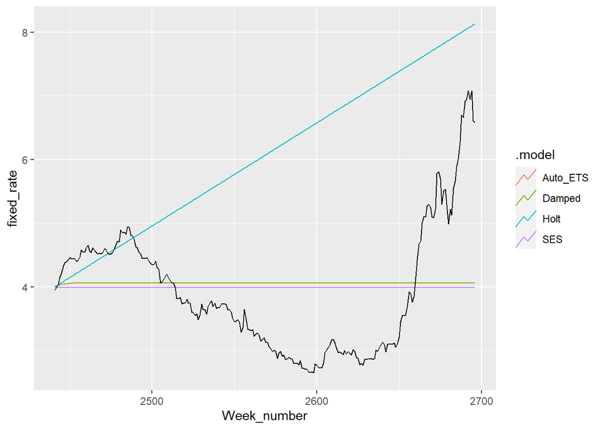

```r
fc2 <- fitETS %>%
  forecast(new_data = test)

fc2 %>% autoplot(test, level =NULL)
```

```r
fitETSlog <- train %>%
  model(SES_log = ETS(log(fixed_rate) ~ error("A") + trend("N") + season("N")),
        Holt_log = ETS(log(fixed_rate) ~ error("A") + trend("A") + season("N")),
        Damped_log = ETS(log(fixed_rate) ~ error("A") + trend("Ad") + season("N")),
        Auto_ETS_log = ETS(log(fixed_rate)),
        SES = ETS(fixed_rate ~ error("A") + trend("N") + season("N")),
        Holt = ETS(fixed_rate ~ error("A") + trend("A") + season("N")),
        Damped = ETS(fixed_rate ~ error("A") + trend("Ad") + season("N")),
        Auto_ETS = ETS(fixed_rate))

        fitETSlog %>% glance
```

```
## # A tibble: 8 × 9
##   .model         sigma2 log_lik    AIC   AICc    BIC      MSE     AMSE     MAE
##   <chr>           <dbl>   <dbl>  <dbl>  <dbl>  <dbl>    <dbl>    <dbl>   <dbl>
## 1 SES_log      0.000201    880. -1754. -1754. -1737. 0.000200 0.000470 0.00951
## 2 Holt_log     0.000201    880. -1750. -1750. -1721. 0.000200 0.000470 0.00952
## 3 Damped_log   0.000194    920. -1827. -1827. -1793. 0.000194 0.000453 0.00928
## 4 Auto_ETS_log 0.000194    920. -1827. -1827. -1793. 0.000194 0.000453 0.00928
## 5 SES          0.0123    -4035.  8076.  8076.  8093. 0.0123   0.0338   0.0713
## 6 Holt         0.0119    -3994.  7998.  7998.  8027. 0.0119   0.0359   0.0724
## 7 Damped       0.0110    -3892.  7796.  7796.  7830. 0.0109   0.0299   0.0689
## 8 Auto_ETS     0.0110    -3892.  7796.  7796.  7830. 0.0109   0.0299   0.0689
```

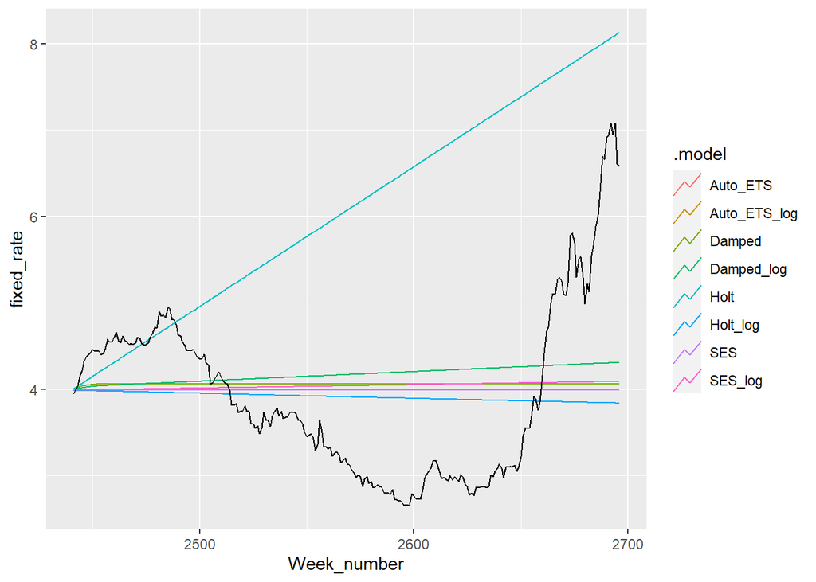

```r
fc3 <- fitETSlog %>%
  forecast(new_data = test)
fc3 %>% autoplot(test, level =NULL)
```

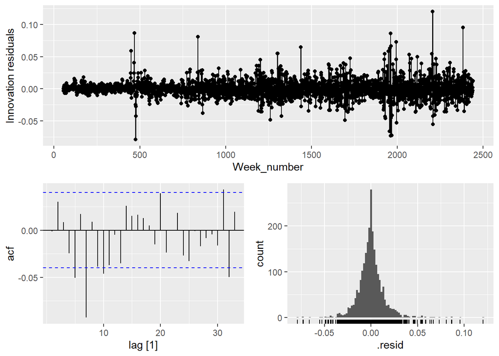

```r
fitETSBESTModel <- train %>%
  model(Damped = ETS(log(fixed_rate) ~ error("A") + trend("Ad") + season("N")))
AUG2 <- augment(fitETSBESTModel)

fitETSBESTModel %>% gg_tsresiduals()
```

```r
AUG2 %>% features(.innov, unitroot_kpss)
```

```
## # A tibble: 1 × 3
##   .model kpss_stat kpss_pvalue
##   <chr>      <dbl>       <dbl>
## 1 Damped     0.143         0.1
```

I chose to use the dampened log model because taking the log of the data made it more stationary.

The damped model worked the best, it is also the one that the Auto ETS picked out.

Residuals have peaks where they seem unstationary but residuals are relatively stationary.

```r
Dataset_tsb_updated %>% features(diff_fixed_rate, unitroot_kpss)
```

```
## # A tibble: 1 × 2
##   kpss_stat kpss_pvalue
##       <dbl>       <dbl>
## 1     0.144         0.1
```

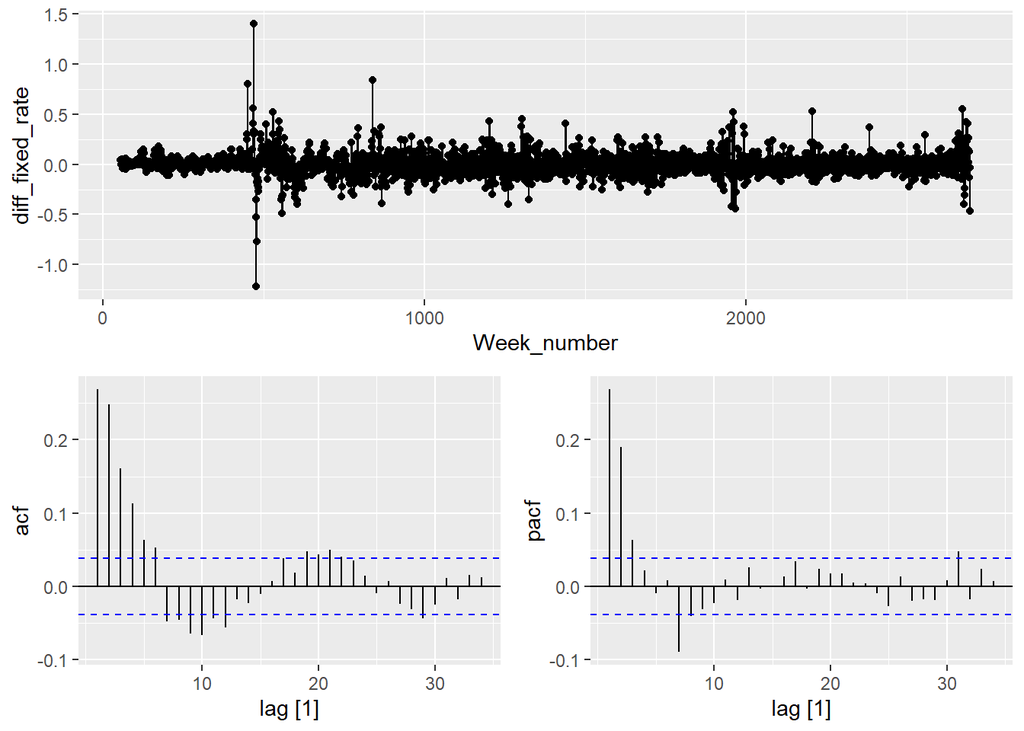

```r
Dataset_tsb_updated %>% gg_tsdisplay(diff_fixed_rate, plot_type = "partial")
```

Looks like an AR model.

```r
fitARIMA_diff_fixed <- train %>% model( ARIMA1 = ARIMA(diff_fixed_rate ~ pdq(0,0,0)),
                                 ARIMA2 = ARIMA(diff_fixed_rate ~ pdq(2,0,0)),
                                 ARIMA3 = ARIMA(diff_fixed_rate ~ pdq(1,0,0)),
                                 ARIMA4 = ARIMA(diff_fixed_rate))

fitARIMA_diff_fixed %>% glance
```

```
## # A tibble: 4 × 8
##   .model sigma2 log_lik    AIC   AICc    BIC ar_roots  ma_roots
##   <chr>   <dbl>   <dbl>  <dbl>  <dbl>  <dbl> <list>    <list>
## 1 ARIMA1 0.0123   1858. -3714. -3714. -3708. <cpl [0]> <cpl [0]>
## 2 ARIMA2 0.0109   2003. -4001. -4001. -3984. <cpl [2]> <cpl [0]>
## 3 ARIMA3 0.0114   1956. -3908. -3908. -3897. <cpl [1]> <cpl [0]>
## 4 ARIMA4 0.0108   2017. -4024. -4024. -3996. <cpl [2]> <cpl [2]>
```

```r
fitARIMA_diff_fixed %>% glimpse
```

```
## Rows: 1
## Columns: 4
## $ ARIMA1 <model> [ARIMA(0,0,0)]
## $ ARIMA2 <model> [ARIMA(2,0,0)]
## $ ARIMA3 <model> [ARIMA(1,0,0)]
## $ ARIMA4 <model> [ARIMA(2,0,2)]
```

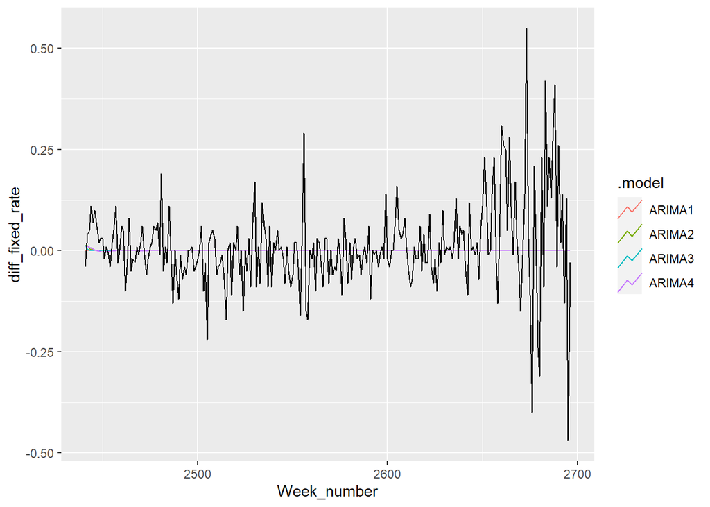

```r
fc4 <- fitARIMA_diff_fixed %>%
  forecast(new_data = test)
fc4 %>% autoplot(test, level =NULL)
```

```r
 fitARIMA_fixed <-  train %>% model(ARIMA5 = ARIMA(fixed_rate ~ pdq(1,1,0)),
                                ARIMA6 = ARIMA(fixed_rate ~ pdq(2,1,0)),
                                 ARIMA7 = ARIMA(fixed_rate ~ pdq(1,1,0)),
                                ARIMA8 = ARIMA(fixed_rate))

fitARIMA_fixed %>% glance
```

```
## # A tibble: 4 × 8
##   .model sigma2 log_lik    AIC   AICc    BIC ar_roots  ma_roots
##   <chr>   <dbl>   <dbl>  <dbl>  <dbl>  <dbl> <list>    <list>
## 1 ARIMA5 0.0114   1955. -3906. -3906. -3894. <cpl [1]> <cpl [0]>
## 2 ARIMA6 0.0109   2002. -3998. -3998. -3981. <cpl [2]> <cpl [0]>
## 3 ARIMA7 0.0114   1955. -3906. -3906. -3894. <cpl [1]> <cpl [0]>
## 4 ARIMA8 0.0108   2016. -4022. -4022. -3993. <cpl [2]> <cpl [2]>
```

```r
fitARIMA_fixed %>% glimpse
```

```
## Rows: 1
## Columns: 4
## $ ARIMA5 <model> [ARIMA(1,1,0)]
## $ ARIMA6 <model> [ARIMA(2,1,0)]
## $ ARIMA7 <model> [ARIMA(1,1,0)]
## $ ARIMA8 <model> [ARIMA(2,1,2)]
```

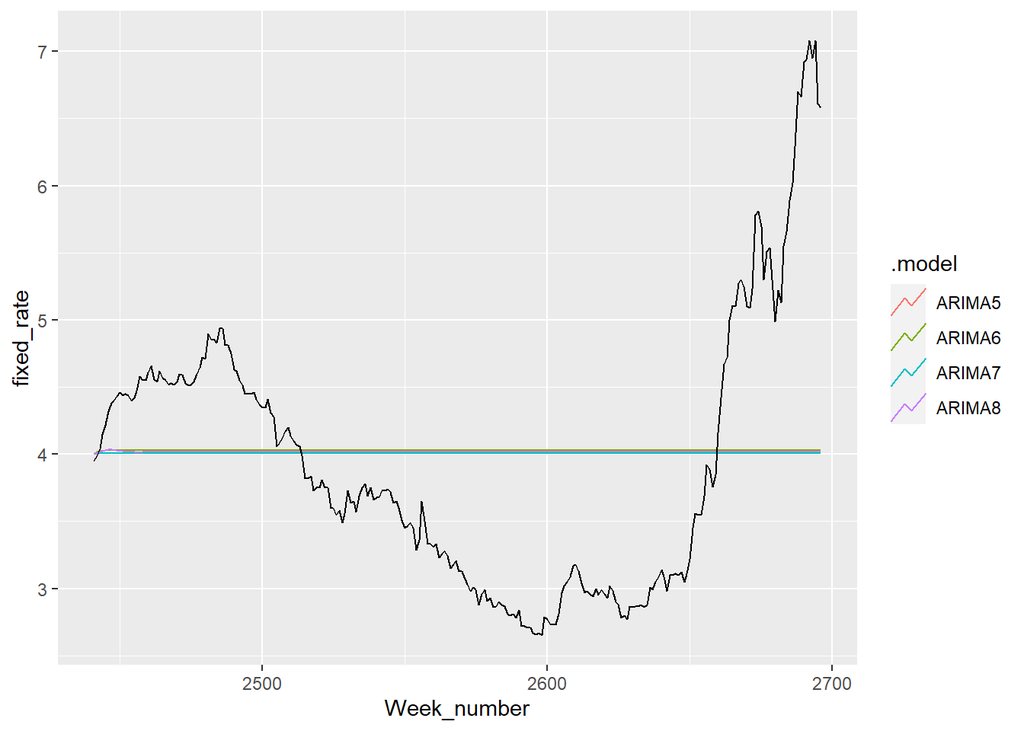

```r
fc5 <- fitARIMA_fixed %>%
  forecast(new_data = test)
fc5 %>% autoplot(test, level =NULL)
```

Will use Auto ARIMA for diff_fixed_rate which (2,0,2) for pdq

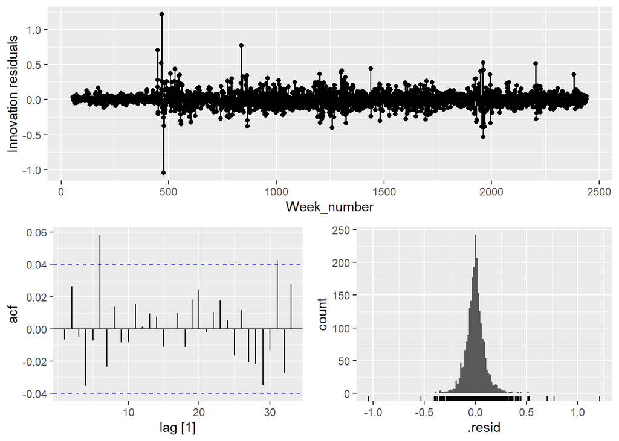

```r
fitBestARIMAmodel <- train %>% model(ARIMABEST = ARIMA(diff_fixed_rate))

AUG3 <- augment(fitBestARIMAmodel)

fitBestARIMAmodel %>% gg_tsresiduals()
```

```r
AUG3 %>% features(.innov, unitroot_kpss)
```

```
## # A tibble: 1 × 3
##   .model    kpss_stat kpss_pvalue
##   <chr>         <dbl>       <dbl>
## 1 ARIMABEST     0.211         0.1
```

There seems to be a small degree of correlation.

Residuals looks stationary for this ARIMA model

```r
fitNNAR <- train %>%
  model(NNAR1 = NNETAR((fixed_rate)))




fitNNAR %>% glimpse
```

```
## Rows: 1
## Columns: 1
## $ NNAR1 <model> [NNAR(4,2)]
```

```r
fitNNAR %>% glance
```

```
## # A tibble: 1 × 2
##   .model sigma2
##   <chr>   <dbl>
## 1 NNAR1  0.0104
```

```r
#fc6 <- fitNNAR %>%
#fc %>% autoplot(test, level =NULL)
```

Struggled to get the NNETAR model to run. Maybe it will run on a different computer. Take out # above to run model

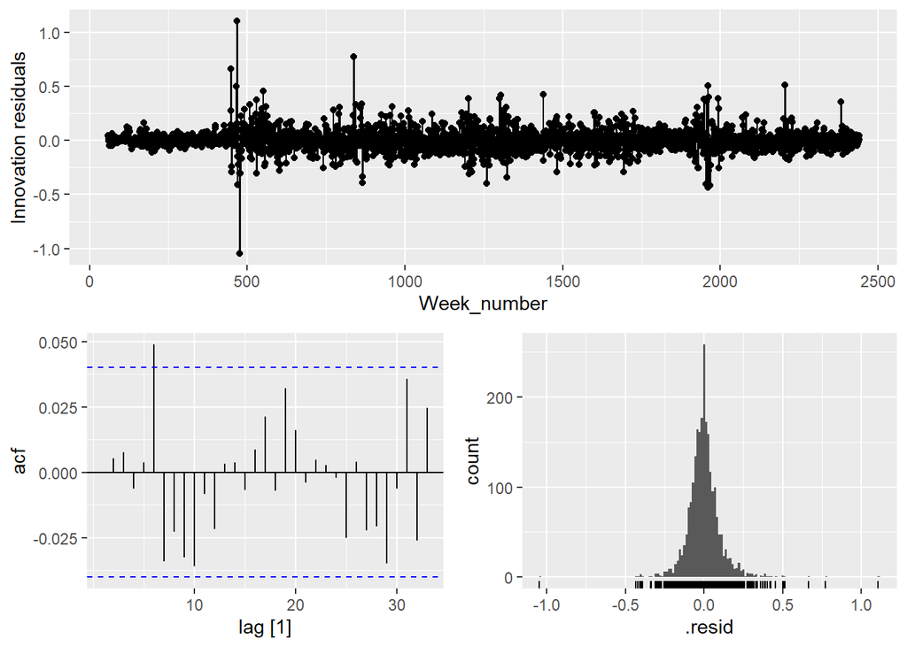

```r
AUG3 <- augment(fitNNAR)

fitNNAR %>% gg_tsresiduals()
```

```r
AUG3 %>% features(.innov, unitroot_kpss)
```

```
## # A tibble: 1 × 3
##   .model kpss_stat kpss_pvalue
##   <chr>      <dbl>       <dbl>
## 1 NNAR1      0.291         0.1
```

There does not appear to be a very high level of autocorrelation.

Data looks stationary for NNETAR model.

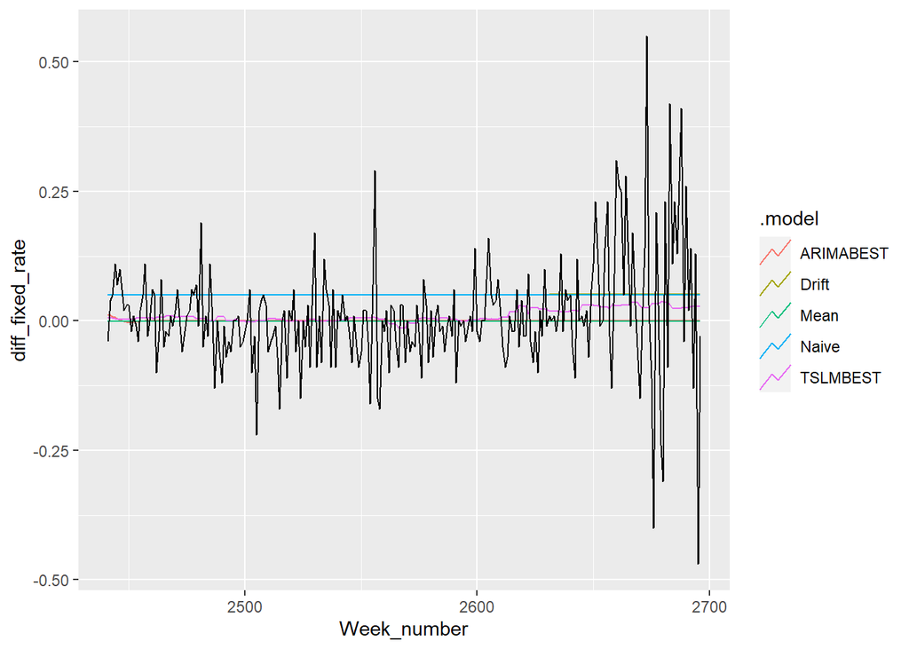

```r
fit_model_compare_diff <- train %>%
  model(TSLMBEST = TSLM(diff_fixed_rate ~ Two_month_lag_CPI +Three_month_lag_CPI + one_year_lag_fixed_rate),
     ARIMABEST = ARIMA(diff_fixed_rate),
     Mean = MEAN(diff_fixed_rate),
     Naive = NAIVE(diff_fixed_rate),
     Drift = RW(diff_fixed_rate ~ drift()))






forecast_diff <- fit_model_compare_diff %>%
  forecast(new_data = test)
forecast_diff %>% autoplot(test, level =NULL)
```

```r
forecast_diff %>% accuracy(Dataset_tsb_updated)
```

```
## # A tibble: 5 × 10
##   .model    .type        ME  RMSE    MAE   MPE  MAPE  MASE RMSSE  ACF1
##   <chr>     <chr>     <dbl> <dbl>  <dbl> <dbl> <dbl> <dbl> <dbl> <dbl>
## 1 ARIMABEST Test   0.0100   0.110 0.0709   NaN   Inf 0.817 0.824 0.140
## 2 Drift     Test  -0.0404   0.116 0.0857  -Inf   Inf 0.987 0.875 0.140
## 3 Mean      Test   0.0115   0.110 0.0711   Inf   Inf 0.820 0.825 0.141
## 4 Naive     Test  -0.0399   0.116 0.0854  -Inf   Inf 0.985 0.874 0.141
## 5 TSLMBEST  Test  -0.000302 0.108 0.0708   NaN   Inf 0.816 0.808 0.112
```

```r
#fit_model_compare <- train %>%
#  model(NNETAR = NNETAR(sqrt(fixed_rate)),
#ETSBest = ETS(log(fixed_rate) ~ error("A") + trend("Ad") + season("N")))


#fit_model_compare %>% glance


#forecast <- fit_model_compare %>%
  #forecast(new_data = test)
#forecast %>% autoplot(test, level =NULL)

#forecast %>% accuracy(Dataset_tsb_updated)


#forecast()
```

I chose RMSE statistic because I want the dataset to be more sensitive to big outliers and be able to account for large outleirs in the future. I chose TSLM because it had the lowest RMSE and also had the lowest MAEand MASE statistics. It also seemed to do a better job of predicting the test data from an eye test when forecasted out. Plus it had three predictor variables that all had levels of correlation to the fixed mortgage rate and difference of fixed mortgage rate. I was never able to get NNETAR to run so I commented it out. Feel free to try to run it and see if it is better.

I couldn’t figure out how to fit the ETS model with the others most likely since I took the log of fixed_rate instead of using diff_fixed_rate. I ran it below and looked at its accuracy along with NNETAR but I was unable to view NNETAR’s accuracy from my previous issues with NNETAR. Take out # to run NNETAR and ETS

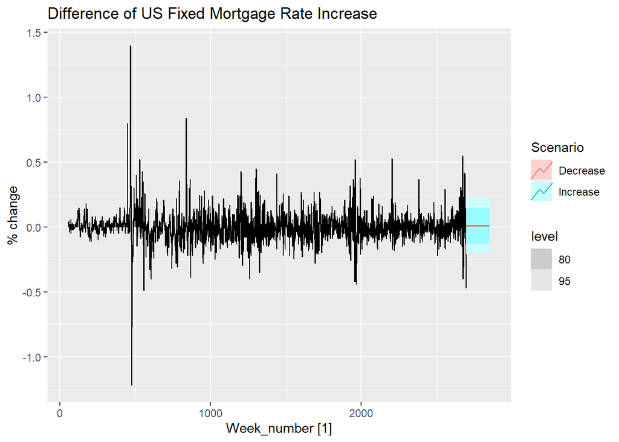

```r
Model_Picked <- Dataset_tsb_updated %>%
 model(TSLMBEST = TSLM(diff_fixed_rate ~ Two_month_lag_CPI +Three_month_lag_CPI + one_year_lag_fixed_rate)
  )


diff_fixed_rate.lm = lm(diff_fixed_rate ~ Two_month_lag_CPI +Three_month_lag_CPI + one_year_lag_fixed_rate, data=Dataset_tsb_updated)#using this equation to find the  the coefficents


future_scenarios <- scenarios(
  Increase = new_data(Dataset_tsb_updated, 156) %>%
    mutate(Two_month_lag_CPI =.1, Three_month_lag_CPI=.06, one_year_lag_fixed_rate=0.03),
  Decrease = new_data(Dataset_tsb_updated, 156) %>%
    mutate(Two_month_lag_CPI=-.11, Three_month_lag_CPI=-0.06, one_year_lag_fixed_rate=-.03),
  names_to = "Scenario")




fcast <- forecast(Model_Picked, new_data = future_scenarios)

Dataset_tsb_updated %>%
  autoplot(diff_fixed_rate) +
  autolayer(fcast) +
  labs(title = "Difference of US Fixed Mortgage Rate Increase", y = "% change")
```

I forecasted 3 years into the future and that was to give it a long enough time to implement the future scenarios.

Some things to watch out for is if there a depression soon, it will most likely have an effect on fixed mortgage rates as well as if inflation keeps increasing as well. If the economy recovers quickly the fixed mortgage rates will probably decrease as well.